# Análisis Estadístico Multivariante

Práctica 5: Análisis Discriminante

Francisco Javier Mercader Martínez

**PRÁCTICA 5: ANÁLISIS DISCRIMINANTE**

ANÁLISIS ESTADÍSTICO MULTIVARIANTE

GRADO EN CIENCIA E INGENIERÍA DE DATOS

**Sumario**: En esta práctica mostramos cómo clasificar individuos entre diversos grupos a partir de sus medidas en algunas variables. Para ello necesitaremos disponer de una muestra de las variables en estudio en individuos de cada grupo (al menos dos individuos por cada grupo) (clasificación supervisada). Necesitaremos instalar los siguientes paquetes: **MASS, dplyr, mvtnorm, mvnormtest**.

# 1. Estudio descriptivo inicial

Como en el resto de las técnicas aplicadas previamente, es conveniente hacer un análisis inicial del conjunto de datos. En este caso trataremos de estudiar las diferencias de las variables en cada uno de los grupos para dilucidar si serán de utilidad a la hora de clasificar (discriminar) a los individuos de los distintos grupos.

Comenzaremos leyendo los datos del objeto **d** del fichero **escarabajos.rda** (disponible en el aula virtual). Para cargar este archivo utilizamos la función *load*, indicando la ruta completa en dónde se encuentra el archivo o cambiando el directorio de trabajo.

```r
load("../data/escarabajos.rda")
```

Empezamos mostrando la estructura del conjunto de datos:

```r
## completar aquí
str(d)
```

```
## 'data.frame':    40 obs. of  6 variables:
##  $ surco  : num  189 192 217 221 171 192 213 192 170 201 ...
##  $ long   : num  245 260 276 299 239 262 278 255 244 276 ...
##  $ base2  : num  137 132 141 142 128 147 136 128 128 146 ...
##  $ base3  : num  163 217 192 213 158 173 201 185 192 186 ...
##  $ especie: Factor w/ 3 levels "* ","HC","HO": 3 3 3 3 3 3 3 3 3 3 ...
##  $ codigo : int  1 1 1 1 1 1 1 1 1 1 ...
```

Hacemos un resumen numérico:

```r
## completar aquí
summary(d)
```

```
##      surco            long           base2           base3       especie
##  Min.   :158.0   Min.   :237.0   Min.   :121.0   Min.   :158.0   * : 1
##  1st Qu.:177.0   1st Qu.:262.8   1st Qu.:137.8   1st Qu.:187.5   HC:20
##  Median :183.1   Median :278.0   Median :146.0   Median :194.5   HO:19
##  Mean   :186.7   Mean   :279.0   Mean   :147.4   Mean   :197.7
##  3rd Qu.:192.8   3rd Qu.:299.0   3rd Qu.:160.5   3rd Qu.:213.0
##  Max.   :221.0   Max.   :317.0   Max.   :184.0   Max.   :235.0
##
##      codigo
##  Min.   :1.000
##  1st Qu.:1.000
##  Median :2.000
##  Mean   :1.513
##  3rd Qu.:2.000
##  Max.   :2.000
##  NA's   :1
```

Si queremos visualizar el conjunto de datos completo podemos utilizar el comando *View(d)*. También podemos ver las primeras filas del conjunto de datos:

```r
## completar aquí
head(d, n=6)
```

```
##   surco long base2 base3 especie codigo
## 1   189  245   137   163      HO      1
## 2   192  260   132   217      HO      1
## 3   217  276   141   192      HO      1
## 4   221  299   142   213      HO      1
## 5   171  239   128   158      HO      1
## 6   192  262   147   173      HO      1
```

Comprobaremos así que dicho fichero contiene una muestra de 40 escarabajos de dos especies diferentes Haltica Oleracea (HO) y Haltica Carduorum (HC) a los que se les han medido cuatro variables:

surco (X1): distancia desde el tórax al surco transversal (micras),

long (X2): longitud (0.01 mm.),

base2 (X3): longitud de la base de las antenas secundarias (micras),

base3 (X4): longitud de la base de las antenas terciarias (micras).

Las variables especie y código indican la especie a la que pertenece cada individuo (HO = 1, HC = 2). Puede observarse que hay un escarabajo (40) del que se desconoce la especie lo que en *R* se especifica con *NA* (*Not Available*).

Podemos comenzar estudiando cada variable por separado. Para ver solo los datos de la variable *surco* haremos:

```r
d$surco
```

```
##  [1] 189.00 192.00 217.00 221.00 171.00 192.00 213.00 192.00 170.00 201.00
## [11] 195.00 205.00 180.00 192.00 200.00 192.00 200.00 181.00 192.00 181.00
## [21] 158.00 184.00 171.00 181.00 181.00 177.00 198.00 180.00 177.00 176.00
## [31] 192.00 176.00 169.00 164.00 181.00 192.00 181.00 175.00 197.00 182.22
```

```r
## d[, 1] # Otra forma
```

Por ejemplo, para analizar el comportamiento de esta variable, podemos comenzar calculando sus estadísticos básicos (medias, cuartiles y valores extremos) en cada grupo haciendo:

```r
tapply(d$surco, d$especie, summary)
```

```
## $`* `
##    Min. 1st Qu.  Median    Mean 3rd Qu.    Max.
##   182.2   182.2   182.2   182.2   182.2   182.2
##
## $HC
##    Min. 1st Qu.  Median    Mean 3rd Qu.    Max.
##   158.0   175.8   180.5   179.6   181.8   198.0
##
## $HO
##    Min. 1st Qu.  Median    Mean 3rd Qu.    Max.
##   170.0   190.5   192.0   194.5   200.5   221.0
```

De esta forma observamos que la media de la variable surco es mayor en la especie HO (194.5) que en la HC (179.6) y que su valor en el escarabajo 40 (182.2) está más cerca de la media de la especie HC.

También podemos representarla gráficamente indicando dónde se encuentra el escarabajo 40 a la altura 1.5:

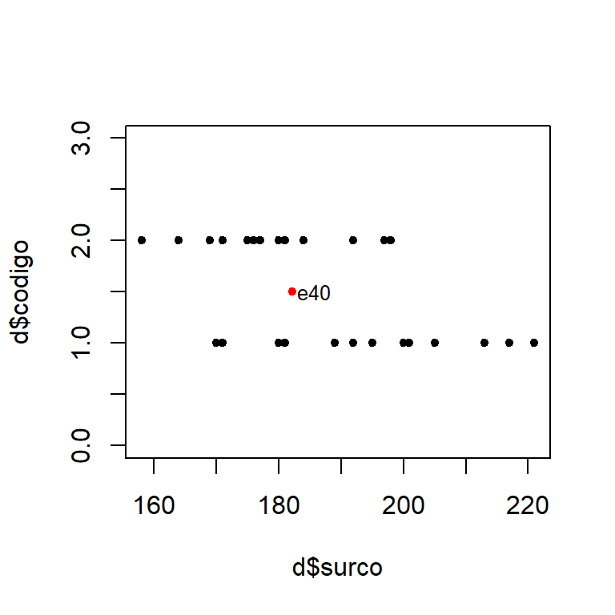

```r
plot(d$surco, d$codigo, ylim = c(0, 3), pch = 20)
points(d$surco[40], 1.5, pch = 20, col = "red")
text(d$surco[40] + 3.5, 1.5, labels = "e40", cex = 0.8)
```

En esta gráfica podemos observar que la variable *surco* parece un poco mayor en el grupo 1 (HO) pero que no discrimina (separa) bien a los grupos. Con esta variable no es sencillo clasificar al escarabajo 40 pero si tenemos que elegir un grupo lo incluiríamos en el grupo 2 (HC) ya que está más cerca de su media.

Se obtiene una gráfica similar haciendo

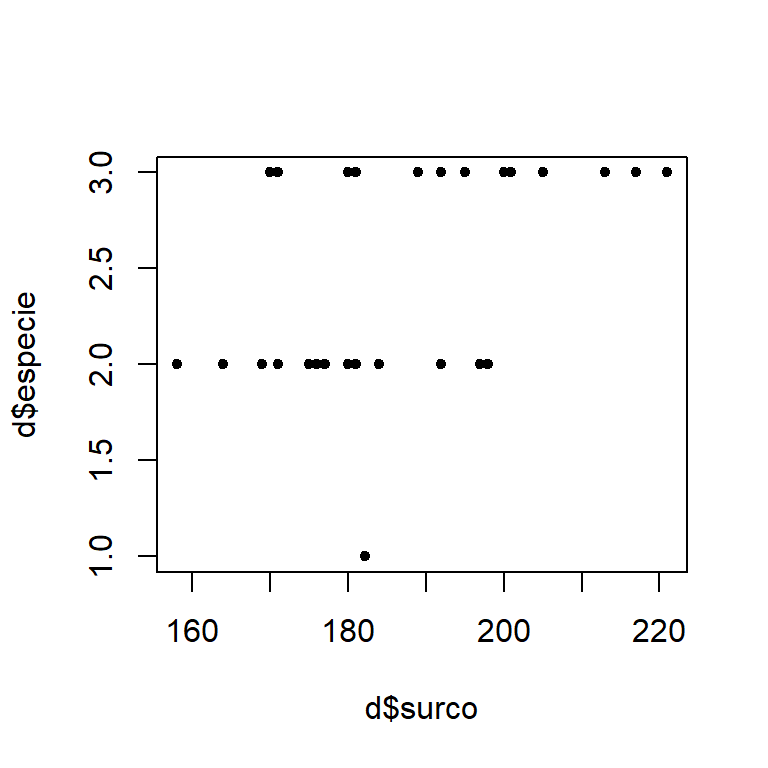

```r
plot(d$surco, d$especie, pch = 20)
```

En este caso, *R* etiqueta los datos por orden alfabético (ASCII) con * = 1, HC = 2 y HO = 3.

Continuamos estudiando las restantes variables. Para la variable *long* tendremos:

```r
## completar aquí
d$long
```

```
##  [1] 245.00 260.00 276.00 299.00 239.00 262.00 278.00 255.00 244.00 276.00
## [11] 242.00 263.00 252.00 283.00 294.00 277.00 287.00 255.00 287.00 305.00
## [21] 237.00 300.00 273.00 297.00 308.00 301.00 308.00 286.00 299.00 317.00
## [31] 312.00 285.00 287.00 265.00 308.00 276.00 278.00 271.00 303.00 271.01
```

Y el siguiente resumen numérico por grupos:

```r
## completar aquí
tapply(d$long, d$especie, summary)
```

```
## $`* `
##    Min. 1st Qu.  Median    Mean 3rd Qu.    Max.
##     271     271     271     271     271     271
##
## $HC
##    Min. 1st Qu.  Median    Mean 3rd Qu.    Max.
##   237.0   277.5   298.0   290.8   305.8   317.0
##
## $HO
##    Min. 1st Qu.  Median    Mean 3rd Qu.    Max.
##   239.0   253.5   263.0   267.1   280.5   299.0
```

En este caso observamos que la media de la variable *long* es mayor en la especie HC (290.8) que en la HO (267.1) y que su valor en el escarabajo 40 (271) está más cerca de la media de la especie HO.

Y la representación gráfica:

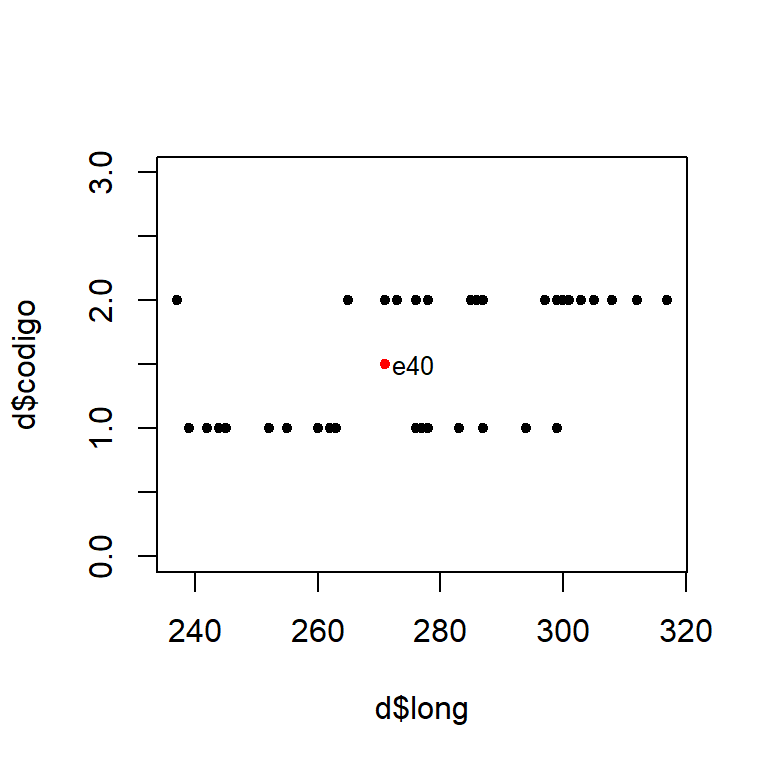

```r
## completar aquí
plot(d$long, d$codigo, ylim=c(0,3), pch=20)
points(d$long[40], 1.5, pch=20, col="red")
text(d$long[40] + 4.5, 1.5, labels = "e40", cex=0.8)
```

En esta gráfica podemos observar que la variable *long* parece un poco menor en el grupo 1 (HO) pero que no discrimina (separa) bien a los grupos. Según esta variable, al escarabajo 40 lo clasificaríamos en el grupo 1 (HO) ya que está más cerca de su media.

Para la variable *base2* tendremos:

```r
## completar aquí
d$base2
```

```
##  [1] 137.00 132.00 141.00 142.00 128.00 147.00 136.00 128.00 128.00 146.00
## [11] 128.00 147.00 121.00 138.00 138.00 150.00 136.00 146.00 141.00 184.00
## [21] 133.00 166.00 162.00 163.00 160.00 166.00 141.00 146.00 171.00 166.00
## [31] 166.00 141.00 162.00 147.00 157.00 154.00 149.00 140.00 170.00 140.99
```

Y el siguiente resumen numérico por grupos:

```r
## completar aquí
tapply(d$base2, d$especie, summary)
```

```
## $`* `
##    Min. 1st Qu.  Median    Mean 3rd Qu.    Max.
##     141     141     141     141     141     141
##
## $HC
##    Min. 1st Qu.  Median    Mean 3rd Qu.    Max.
##   133.0   146.8   161.0   157.2   166.0   184.0
##
## $HO
##    Min. 1st Qu.  Median    Mean 3rd Qu.    Max.
##   121.0   130.0   138.0   137.4   144.0   150.0
```

La media de la variable *base2* es mayor en la especie HC (157.2) que en la HO (137.4) y que su valor en el escarabajo 40 (141) está más cerca de la media de la especie HO. Si hacemos la representación gráfica:

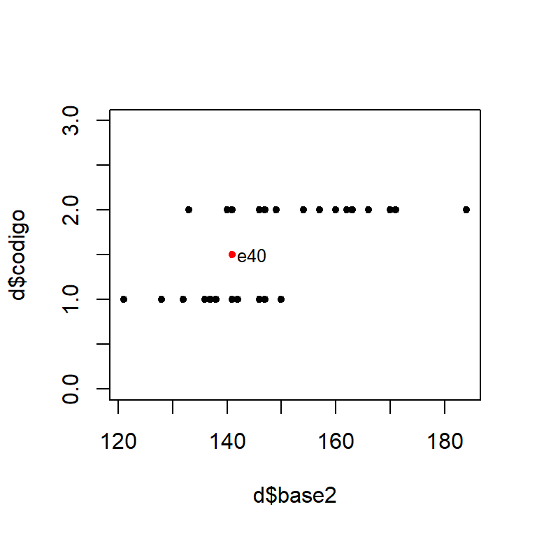

```r
## completar aquí
plot(d$base2, d$codigo, ylim=c(0,3), pch=20)
points(d$base2[40], 1.5, pch=20, col="red")
text(d$base2[40] + 3.5, 1.5, labels = "e40", cex=0.8)
```

Para la variable *base3* se observan los valores:

```r
d$base3
```

```
##  [1] 163.00 217.00 192.00 213.00 158.00 173.00 201.00 185.00 192.00 186.00
## [11] 192.00 192.00 167.00 183.00 188.00 177.00 173.00 183.00 198.00 209.00
## [21] 188.00 231.00 213.00 224.00 223.00 221.00 197.00 214.00 192.00 213.00
## [31] 209.00 200.00 214.00 192.00 204.00 209.00 235.00 192.00 205.00 190.15
```

Y obtenemos el siguiente resumen numérico por grupos:

```r
## completar aquí
tapply(d$base3, d$especie, summary)
```

```
## $`* `
##    Min. 1st Qu.  Median    Mean 3rd Qu.    Max.
##   190.1   190.1   190.1   190.1   190.1   190.1
##
## $HC
##    Min. 1st Qu.  Median    Mean 3rd Qu.    Max.
##   188.0   199.2   209.0   209.2   215.8   235.0
##
## $HO
##    Min. 1st Qu.  Median    Mean 3rd Qu.    Max.
##   158.0   175.0   186.0   185.9   192.0   217.0
```

La media de la variable *base3* es mayor en la especie HC (209.2) que en la HO (185.9) y que el valor para el escarabajo 40 (190.1) está más cerca de la media de la especie HO. Y la representación gráfica vendrá dada por:

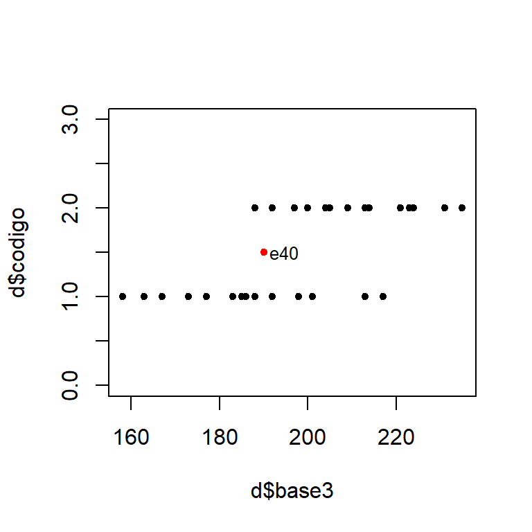

```r
## completar aquí
plot(d$base3, d$codigo, ylim=c(0,3), pch=20)
points(d$base3[40], 1.5, pch=20, col="red")
text(d$base3[40] + 4.5, 1.5, labels = "e40", cex=0.8)
```

Para visualizar estas diferencias también podemos usar los gráficos caja-bigote por grupos.

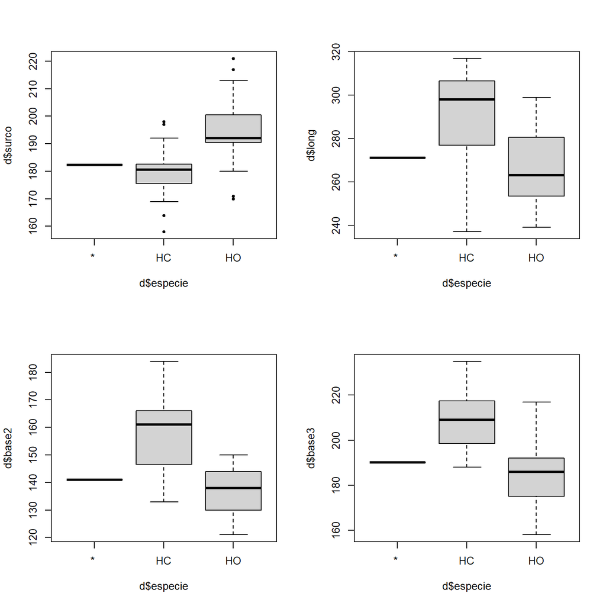

```r
par(mfrow = c(2, 2))
boxplot(d$surco ~ d$especie, pch = 20)
boxplot(d$long ~ d$especie, pch = 20)
boxplot(d$base2 ~ d$especie, pch = 20)
boxplot(d$base3 ~ d$especie, pch = 20)
```

En estos gráficos apreciamos que si usáramos solo la variable *surco* para clasificar, como las cajas no se solapan, más del 75% de los individuos se clasificarían bien. También observamos que el escarabajo 40 estaría en la caja de la especie HC (por poco) pero que no sería un valor atípico en la HO. En ambas especies hay observaciones atípicas (para la distribución normal).

En segundo lugar podemos estudiar las variables por parejas. Por ejemplo, para analizar *surco* y *long*, podemos hacer:

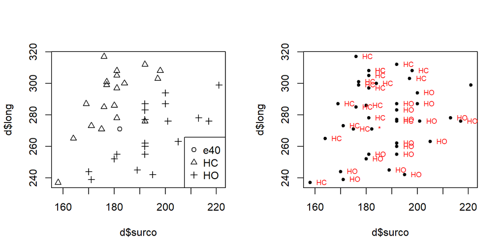

```r
par(mfrow = c(1, 2))
plot(d$surco, d$long, pch = as.integer(d$especie))
legend("bottomright", legend = c("e40", "HC", "HO"), pch = 1:3)

plot(d$surco, d$long, pch = 20)
text(d$surco, d$long, d$especie, cex = 0.7, pos = 4, col = "red")
```

(el argumento cex indica el tamaño y pos la posición de la etiqueta). En esta última gráfica se observa que, con estas dos variables, los dos 2 grupos están bastante separados, pero que el escarabajo 40 estaría entre ambos grupos por lo que no es sencillo clasificarlo.

Representamos ahora el gráfico de las otras dos variables:

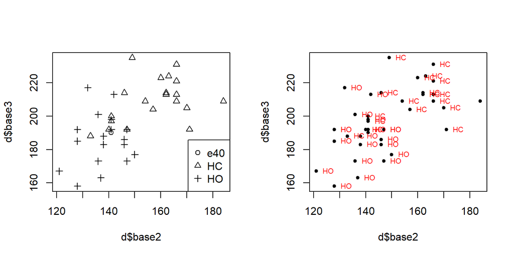

```r
## completar aquí
par(mfrow = c(1,2))
plot(d$base2, d$base3, pch=as.integer(d$especie))
legend("bottomright", legend = c("e40", "HC", "HO"), pch = 1:3)

plot(d$base2, d$base3, pch = 20)
text(d$base2, d$base3, d$especie, cex = 0.7, pos = 4, col = "red")
```

Finalmente, podemos hacer un gráfico similar al anterior pero usando las dos primeras componentes principales (ver práctica 4) que contienen información sobre todas las variables. Recordemos que las componentes principales (basadas en la matriz de correlaciones) y las puntuaciones (*scores*) se calculan con:

```r
PCA <- princomp(d[, 1:4], cor = TRUE)
S <- PCA$scores
```

y que se pueden representar las dos primeras componentes por grupos con los gráficos:

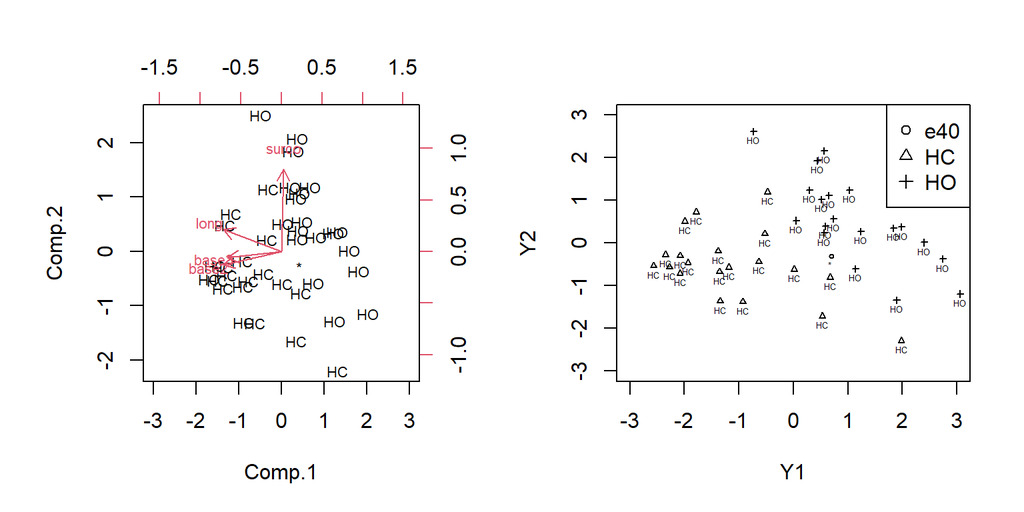

```r
par(mfrow = c(1, 2))
biplot(PCA, pc.biplot = TRUE, xlabs = d$especie, cex = 0.7, xlim = c(-3, 3))

plot(S[, 1], S[, 2], xlab = 'Y1', ylab = 'Y2', pch = as.integer(d$especie), cex = 0.5,
     xlim = c(-3, 3), ylim = c(-3, 3))
text(S[, 1], S[, 2]-0.2, labels = d$especie, cex = 0.4)
legend("topright", legend = c("e40", "HC", "HO"), pch = 1:3)
```

En estos gráficos también se aprecia que los grupos se pueden separar bastante bien teniendo el grupo HC medidas grandes en todas las variables excepto en surco. De nuevo, el escarabajo 40 aparece cerca de la frontera entre ambos grupos. Señalar no obstante que las dos primeras componentes principales no son necesariamente las mejores variables para clasificar a estos individuos (como veremos en las secciones siguientes).